# Prediction Assignment Writeup

Oleg

August 29, 2017

### Data and libraries

The training data for this project are available here: https://d396qusza40orc.cloudfront.net/predmachlearn/pml-training.csv

The test data are available here: https://d396qusza40orc.cloudfront.net/predmachlearn/pml-testing.csv

We will use several packages for data analysis:

- library(dplyr)
- library(caret)
- library(randomForest)
- library(ggplot2)

### Cleaning data

There are several data fields that contain useless data for the purpose of prediction analysis:

- Fields containing user names, timestamps, etc.
- Fields containing a lot of error entries, e.g., #DIV/0!
- Fields containing a lot of NA values
- Fields containing a factor type variable with ten-fold levels

```
## 'data.frame':    19622 obs. of  7 variables:
##  $ X                   : int  1 2 3 4 5 6 7 8 9 10 ...
##  $ user_name           : Factor w/ 6 levels "adelmo","carlitos",..: 2 2 2 2 2 2 2 2 2 2 ...
##  $ raw_timestamp_part_1: int  1323084231 1323084231 1323084231 1323084232 1323084232 1323084232 1323084232 1323084232 1323084232 1323084232 ...
##  $ raw_timestamp_part_2: int  788290 808298 820366 120339 196328 304277 368296 440390 484323 484434 ...
##  $ cvtd_timestamp      : Factor w/ 20 levels "02/12/2011 13:32",..: 9 9 9 9 9 9 9 9 9 9 ...
##  $ new_window          : Factor w/ 2 levels "no","yes": 1 1 1 1 1 1 1 1 1 1 ...
##  $ num_window          : int  11 11 11 12 12 12 12 12 12 12 ...
```

```
##  Factor w/ 68 levels "","-0.1","-0.2",..: 1 1 1 1 1 1 1 1 1 1 ...
```

```
##  num [1:19622] NA NA NA NA NA NA NA NA NA NA ...
```

```
##  Factor w/ 2 levels "","#DIV/0!": 1 1 1 1 1 1 1 1 1 1 ...
```

We will do the following steps:

- Remove first seven columns with unusable info
- ID columns containing factors
- Change the factors into numeric variables for all fields, except the output
- Remove fields containing NA

The final set’s dimensions are: 19622, 53.

### Exploratory analysis

Based on the exploratory analysis (please see an excerpt below), we don’t see evidence of linear relationships between independent and dependent variables. Given that, it makes sense to run classification analysis, particularly a random forest analysis.

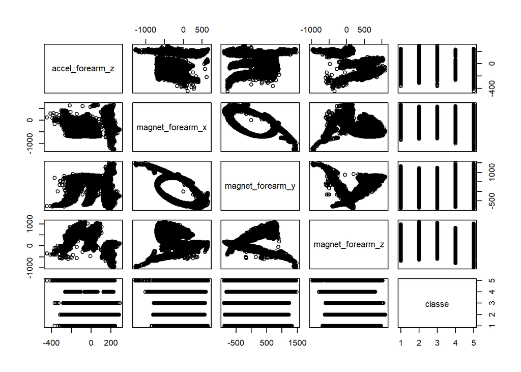

### Creating training and validation sub-sets from the training data

We will use the “caret” package to split the “training” dataset into two subsets: one for training (“tra”) and one for validation (“val”).

### Train the model using “randomForest”

We then train the model on the “tra” dataset using the “randomForest” function. The top 10 most important drivers of the output variable “classe” are illustrated in the chart below.

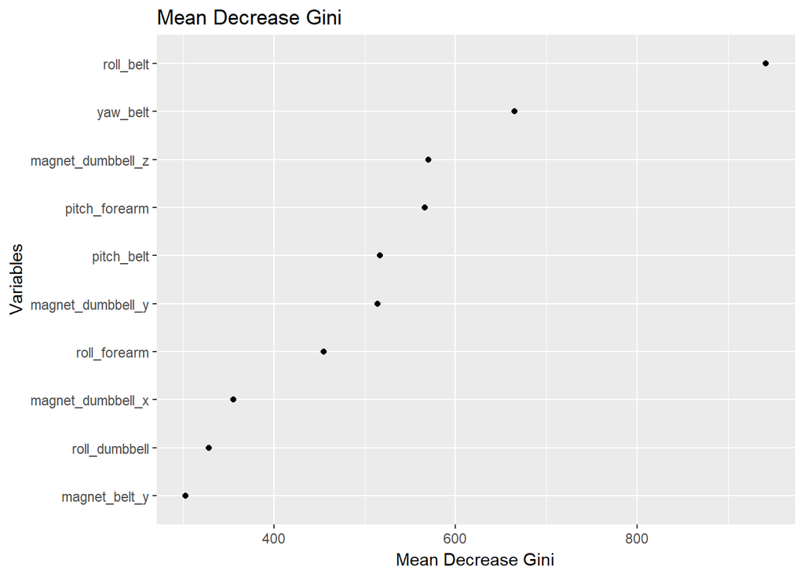

### Check for accuracy

```
## Confusion Matrix and Statistics
##
##           Reference
## Prediction    A    B    C    D    E
##          A 1394    1    0    0    0
##          B    6  943    0    0    0
##          C    0    4  850    1    0
##          D    0    0    2  802    0
##          E    0    0    0    1  900
##
## Overall Statistics
##
##                Accuracy : 0.9969
##                  95% CI : (0.995, 0.9983)
##     No Information Rate : 0.2855
##     P-Value [Acc > NIR] : < 2.2e-16
##
##                   Kappa : 0.9961
##  Mcnemar's Test P-Value : NA
##
## Statistics by Class:
##
##                      Class: A Class: B Class: C Class: D Class: E
## Sensitivity            0.9957   0.9947   0.9977   0.9975   1.0000
## Specificity            0.9997   0.9985   0.9988   0.9995   0.9998
## Pos Pred Value         0.9993   0.9937   0.9942   0.9975   0.9989
## Neg Pred Value         0.9983   0.9987   0.9995   0.9995   1.0000
## Prevalence             0.2855   0.1933   0.1737   0.1639   0.1835
## Detection Rate         0.2843   0.1923   0.1733   0.1635   0.1835
## Detection Prevalence   0.2845   0.1935   0.1743   0.1639   0.1837
## Balanced Accuracy      0.9977   0.9966   0.9982   0.9985   0.9999
```

In-sample accuracy can be derived from cross validation. The fitted model was used to predict the “classe” variable in the validation subset (“val”). The in-sample accuracy is 0.9969413. We can assume the out-sample accuracy to be somewhat worse, but not smaller than the lower limit of the 95% CI, i.e., 0.99.

### Predict the output

Next, we run our random forest model on the “testing” dataset to arrive at predicted values:

```
##    Predicted Classe
## 1                 B
## 2                 A
## 3                 B
## 4                 A
## 5                 A
## 6                 E
## 7                 D
## 8                 B
## 9                 A
## 10                A
## 11                B
## 12                C
## 13                B
## 14                A
## 15                E
## 16                E
## 17                A
## 18                B
## 19                B
## 20                B
```